# Loyalty program in retail.

#### Дополнительная выручка от продажи карт ПЛ.

Данный показатель не является метрикой эффективности ПЛ. Обычно магазины вводят плату за вход в ПЛ, чтобы компенсировать свои затраты на оформление карт и пр., а во избежание раздачи карт "вхолостую".

```python
customers_loyal_count = len(customers_loyal)
month_count = (data['date'].max() - data['date'].min()) / np.timedelta64(1, 'M')
pay_per_month = 200
```

```python
revenue_for_cards = customers_loyal_count * month_count * pay_per_month
total_revenue = data['total'].sum()
print(f'Дополнительная выручка от продажи карт ПЛ за период: {revenue_for_cards:.2f} руб.')
print(f'Это {revenue_for_cards/total_revenue:.2%} от общей выручки за период.')
```

```
Дополнительная выручка от продажи карт ПЛ за период: 343287.54 руб.
Это 15.30% от общей выручки за период.
```

#### Сравнение выручки, среднего чека, среднего количества товаров: участники ПЛ и не-участники ПЛ.

```python
loyalty_params = (data.groupby('loyalty', as_index=False).agg(total_revenue=('total', 'sum'),
                                                              customers=('customer_id', 'nunique'),
                                                              purchases=('purchase_id', 'nunique'),
                                                              items=('item_id', 'nunique'),
                                                              total_items=('item_id', 'count'),
                                                              quantities=('quantity', 'sum'),
                                                              shops=('shop_id', 'nunique')).
                  fillna(0).
                  sort_values(by='total_revenue', ascending=False).
                  reset_index(drop=True)
                 )
```

```python
loyalty_params['avg_revenue'] = loyalty_params['total_revenue'] / loyalty_params['purchases']
loyalty_params['avg_quantity'] = loyalty_params['quantities'] / loyalty_params['purchases']
```

```python
loyalty_params.style.format({'total_revenue':'{:.2f}', 'avg_revenue':'{:.2f}', 'avg_quantity':'{:.2f}'})
```

|  | loyalty | total_revenue | customers | purchases | items | total_items | quantities | shops | avg_revenue | avg_quantity |
| --- | --- | --- | --- | --- | --- | --- | --- | --- | --- | --- |
| 0 | False | 1687116.16 | 1106 | 2579 | 2650 | 52459 | 598693 | 30 | 654.17 | 232.14 |
| 1 | True | 556686.06 | 559 | 1116 | 2166 | 17371 | 208084 | 4 | 498.82 | 186.46 |

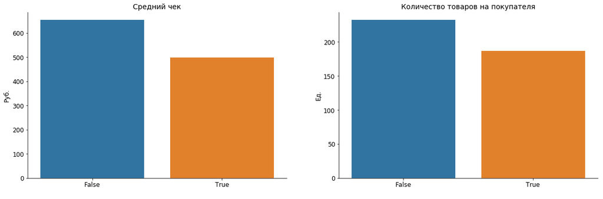

```python
plt.figure(figsize=(20, 6))

ax1 = plt.subplot(1, 2, 1)
ax1 = sns.barplot(x='loyalty', y='avg_revenue', data=loyalty_params, ci=None)
ax1.set_title('Средний чек', fontsize=14)
ax1.tick_params(labelsize=12)
ax1.set_xlabel(' ')
plt.ylabel('Руб.', fontsize=12)
plt.gca().spines['top'].set_alpha(0.0)
plt.gca().spines['bottom'].set_alpha(1)
plt.gca().spines['right'].set_alpha(0.0)
plt.gca().spines['left'].set_alpha(1)

ax2 = plt.subplot(1, 2, 2)
ax2 = sns.barplot(x='loyalty', y='avg_quantity', data=loyalty_params, ci=None)
ax2.set_title('Количество товаров на покупателя', fontsize=14)
ax2.tick_params(labelsize=12)
ax2.set_xlabel(' ')
plt.ylabel('Ед.', fontsize=12)
plt.gca().spines['top'].set_alpha(0.0)
plt.gca().spines['bottom'].set_alpha(1)
plt.gca().spines['right'].set_alpha(0.0)
plt.gca().spines['left'].set_alpha(1)

plt.show()
```

Участники ПЛ посещают только в 4 магазина. Достоверных данных о причинах этого не имеем.

```python
data.query('loyalty == 1').groupby('shop_id').agg({'purchase_id':'nunique'})
```

| shop_id | purchase_id |
| --- | --- |
| Shop 0 | 1110 |
| Shop 19 | 3 |
| Shop 28 | 1 |
| Shop 8 | 2 |

#### Период неактивности Inactivity Period.

Inactivity Period -- интервал времени, прошедший с момента последней активности участника в ПЛ.

```python
lasts = data.groupby('customer_id', as_index=False).agg(last_date=('date', 'max'))
```

```python
ip = data.merge(lasts, on='customer_id')
```

```python
ip['now_date'] = dt.date(2017, 3, 1)
ip['now_date'] = pd.to_datetime(ip['now_date'])
ip['date_delta'] = ip['now_date'] - ip['last_date']
ip['date_delta'] = ip['date_delta'].apply(lambda x: x.days)
```

```python
inactivity_periods = ip.groupby('loyalty', as_index=False).agg(inactivity_period=('date_delta', 'mean'))
inactivity_periods.style.format({'inactivity_period':'{:.2f}'}).background_gradient(cmap='coolwarm')
```

|  | loyalty | inactivity_period |
| --- | --- | --- |
| 0 | False | 28.84 |
| 1 | True | 31.44 |

#### Количество клиентов с более чем 1 покупкой, коэффициент повторной покупки RPR.

RPR -- доля клиентов, которые совершали покупки более одного раза.

RPR= Клиент>1 покупки / Общее количество клиентов в группе клиентов.

```python
more_one_customers_list = (list(data.groupby('customer_id', as_index=False).
                           agg({'purchase_id': 'nunique'}).
                           query('purchase_id > 1')['customer_id'])
                     )
```

```python
more_one_customers = (data.query('customer_id in @more_one_customers_list').
                      groupby('loyalty').
                      agg(customers=('customer_id', 'nunique'))
                     )
all_customers = data.groupby('loyalty').agg(all_customers=('customer_id', 'nunique'))
more_one_customers = more_one_customers.join(all_customers)
more_one_customers['rpr'] = more_one_customers['customers'] / more_one_customers['all_customers']
```

```python
more_one_customers.style.format({'rpr':'{:.2%}'}).background_gradient(cmap='coolwarm')
```

| loyalty | customers | all_customers | rpr |
| --- | --- | --- | --- |
| False | 411 | 1106 | 37.16% |
| True | 242 | 559 | 43.29% |

Коэффициент повторной покупки выше у участников ПЛ.

#### Категоризация покупателей по среднему чеку.

В качестве границ категорий взяли:

```python
small_bill = 100
medium_bill = 1000
```

```python
customers_cat = (data.groupby('customer_id', as_index=False).agg(purchases=('purchase_id', 'nunique'),
                                                                 total_sum=('total', 'sum'),
                                                                 loyal=('loyalty', 'mean')).
                 fillna(0).
                 sort_values(by='total_sum', ascending=False).
                 reset_index(drop=True)
                )
customers_cat['avg_bill'] = round(customers_cat['total_sum'] / customers_cat['purchases'], 2)
```

```python
def categorize_bill(row):
    if row['avg_bill'] < small_bill:
        return 'small'
    elif small_bill <= row['avg_bill'] <= medium_bill:
        return 'medium'
    else:
        return 'large'
```

```python
customers_cat['type'] = customers_cat.apply(categorize_bill, axis=1)
```

```python
customers_cat = customers_cat.groupby(['type', 'loyal']).agg(customers=('customer_id', 'nunique')).reset_index()
```

```python
customers_cat = customers_cat.merge(all_customers, left_on='loyal', right_on='loyalty')
```

```python
customers_cat['share'] = customers_cat['customers'] / customers_cat['all_customers']
customers_cat.style.format({'share':'{:.2%}'})
```

|  | type | loyal | customers | all_customers | share |
| --- | --- | --- | --- | --- | --- |
| 0 | large | False | 133 | 1106 | 12.03% |
| 1 | medium | False | 887 | 1106 | 80.20% |
| 2 | small | False | 86 | 1106 | 7.78% |
| 3 | large | True | 32 | 559 | 5.72% |
| 4 | medium | True | 478 | 559 | 85.51% |
| 5 | small | True | 49 | 559 | 8.77% |

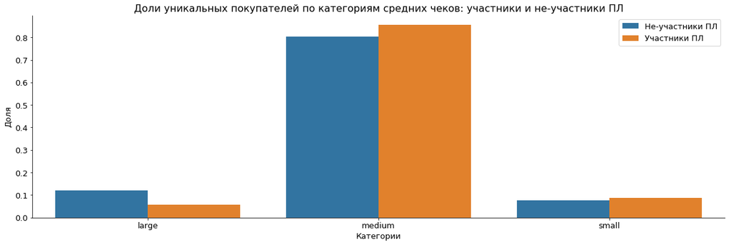

```python
plt.figure(figsize=(20, 6))
ax = plt.subplot()
sns.barplot(x='type', y='share', data=customers_cat, ci=None, hue='loyal')
plt.tick_params(labelsize=13)
plt.title('Доли уникальных покупателей по категориям средних чеков: участники и не-участники ПЛ', fontsize=16)
plt.xlabel('Категории', fontsize=13)
plt.ylabel('Доля', fontsize=13)
plt.legend(['Не-участники ПЛ', 'Участники ПЛ'], fontsize=13)
plt.gca().spines['top'].set_alpha(0.0)
plt.gca().spines['bottom'].set_alpha(1)
plt.gca().spines['right'].set_alpha(0.0)
plt.gca().spines['left'].set_alpha(1)
plt.show()
```

Участники ПЛ больше тяготеют к сегменту `medium`, у них вдвое ниже доля сегмента `large`.

#### Распределение покупок участников ПЛ и не-участников ПЛ во времени.

```python
bills_in_time = (data.groupby('purchase_id').agg(bill_sum=('total', 'sum'),
                                                 date=('date', 'first'),
                                                 loyal=('loyalty', 'mean'))
                )
```

```python
bills_in_time['date'] = bills_in_time['date'].dt.to_period('d')
```

```python
y_false = loyalty_params.set_index('loyalty').at[False, 'avg_revenue']
y_true = loyalty_params.set_index('loyalty').at[True, 'avg_revenue']
```

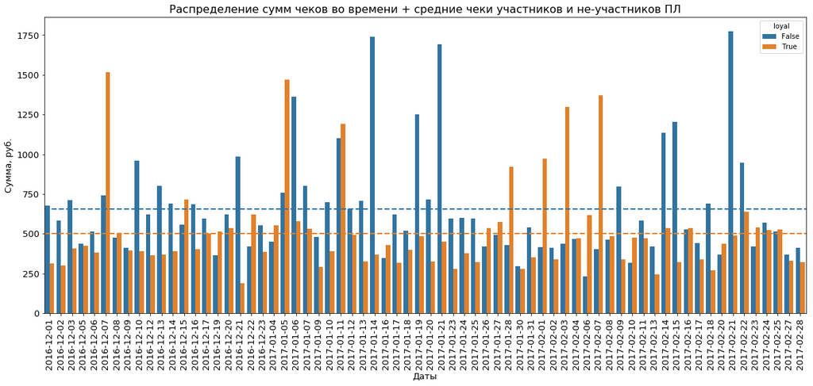

```python
plt.figure(figsize=(20, 8))

ax = plt.subplot()
sns.barplot(x='date', y='bill_sum', data=bills_in_time, ci=None, hue='loyal', alpha=1)
plt.axhline(y=y_false, color='#3274A1', lw=2, linestyle='--')
plt.axhline(y=y_true, color='#E1812C', lw=2, linestyle='--')
plt.title('Распределение сумм чеков во времени + средние чеки участников и не-участников ПЛ', fontsize=16)
plt.xlabel('Даты', fontsize=13)
plt.ylabel('Сумма, руб.', fontsize=13)
plt.xticks(rotation=90, fontsize=10)
plt.tick_params(labelsize=13)

plt.show()
```

**Наблюдаем:**

- коэффициент участия колеблется в диапазоне от 0,25 до 0,4 при среднем 0,35;
- дополнительная выручка от продажи карт ПЛ высокая: около 15 % от всей выручки за период;
- участники ПЛ уступают не-участникам по всем параметрам, в том числе относительным: величине среднего чека и среднем количестве товаров в чеке;
- период неактивности участников ПЛ выше примерно на 3 дня;
- коэффициент повторной покупки выше у участников ПЛ;
- участники ПЛ больше тяготеют к сегменту `medium`, у них вдвое ниже доля сегмента `large`;
- лидерство по абсолютному числу покупателей по всем категориям – за не-участниками ПЛ;
- участники ПЛ лучше удерживаются, совершая повторные покупки, однако пока они менее эффективны в финансовом плане.
- распределение покупок во времени для обеих групп концентрируется вокруг значений средних чеков;
- у обеих групп заметен локальный рост сумм чеков во время новогодних каникул;
- у не-участников ПЛ больше чеков выше среднего, чем у не-участников;
- у обеих групп есть пиковые чеки, появление которых на имеющихся данных мы объяснить не можем.

#### Когортный анализ: LTV.

Для построения когорт необходимо идентицифровать каждого покупателя ==> удалили пропуски в `customer_id`.

```python
data_clean = data.dropna()
```

```python
data_clean.isna().sum()
```

```
purchase_id    0
item_id        0
quantity       0
date_time      0
customer_id    0
shop_id        0
loyalty        0
price          0
total          0
date           0
year           0
week           0
dtype: int64
```

Создали профили пользователей: определяющий признак -- неделя первой покупки; дополнительный признак -- участие в ПЛ.

```python
profiles = (data_clean.sort_values(by=['customer_id', 'date']).
            groupby('customer_id', as_index=False).agg(loyal=('loyalty', 'first'),
                                                       first_purchase=('date_time', 'first'))
           )
profiles['dt'] = profiles['first_purchase'].dt.date
profiles['dt'] = pd.to_datetime(profiles['dt'])
profiles['year'] = profiles['dt'].dt.year
```

```python
profiles.head()
```

|  | customer_id | loyal | first_purchase | dt | year |
| --- | --- | --- | --- | --- | --- |
| 0 | 18026.0 | False | 2016-12-07 14:57:00 | 2016-12-07 | 2016 |
| 1 | 18027.0 | False | 2016-12-16 19:09:00 | 2016-12-16 | 2016 |
| 2 | 18029.0 | False | 2017-02-02 16:01:00 | 2017-02-02 | 2017 |
| 3 | 18031.0 | False | 2017-02-16 12:33:00 | 2017-02-16 | 2017 |
| 4 | 18035.0 | False | 2017-01-18 09:50:00 | 2017-01-18 | 2017 |

**Момент анализа:**

```python
observation_date = pd.to_datetime(dt.date(2017, 3, 1))
observation_date
```

```
Timestamp('2017-03-01 00:00:00')
```

**Горизонт анализа:**

```python
horizon_days = 60
horizon_weeks = round(horizon_days/7)
```

**Плата участника ПЛ в месяц:**

```python
pay_per_month = 200
```

```python
#функция строит матрицу LTV по когортам
def get_ltv(profiles, data, dimensions=[]):
    dimensions = ['loyal', 'year'] + dimensions

    last_suitable_acquisition_date = observation_date - timedelta(days=horizon_days - 1)
    profiles = profiles.query('dt <= @last_suitable_acquisition_date').copy()

    result_raw = profiles.merge(data_clean[['customer_id', 'date', 'total']], on='customer_id')

    result_raw['lifetime'] = (result_raw['date'] - result_raw['dt']).dt.days
    result_raw['lifetime_weeks'] = round(result_raw['lifetime'] / 7, 0)
    result_raw['lifetime_weeks'] = result_raw['lifetime_weeks'].astype('int')
    result_raw['week'] = result_raw['dt'].dt.isocalendar().week
    max_lifetime = result_raw['lifetime_weeks'].max()

    result_grouped = (result_raw.pivot_table(index=['loyal', 'year', 'week'],
                                         columns='lifetime_weeks',
                                         values='total',
                                         aggfunc='sum').
                  fillna(0)
                     )

    cohort_sizes = result_raw.groupby(dimensions).agg(cohort_size=('customer_id', 'nunique'))

    result_grouped = cohort_sizes.merge(result_grouped, on=dimensions)

    #учли по 200 руб. в месяц плату с участников ПЛ
    result_grouped['fees'] = 0
    part_1 = result_grouped.query('loyal == False').copy()
    part_2 = result_grouped.query('loyal == True').copy()
    part_2['fees'] = part_2['cohort_size'] * pay_per_month #размер платы, добавили в каждый 4-ый лайфтайм с 0-го
    result_grouped = part_1.append(part_2)
    for x in range(0, max_lifetime+1, 4):
        result_grouped[x] = result_grouped[x].add(result_grouped['fees'], axis=0)

    result_grouped = result_grouped.drop(columns=['cohort_size', 'fees']).cumsum(axis=1)
    result_grouped['cohort_size'] = cohort_sizes

    result_grouped = result_grouped.div(result_grouped['cohort_size'], axis=0).drop(columns=['cohort_size'])

    result_grouped = result_grouped[list(range(horizon_weeks))]

    return result_raw, result_grouped
```

```python
ltv_raw, ltv = get_ltv(profiles, data_clean, dimensions=['week'])
```

```python
ltv
```

| loyal | year | week | 0 | 1 | 2 | 3 | 4 | 5 | 6 | 7 | 8 |
| --- | --- | --- | --- | --- | --- | --- | --- | --- | --- | --- | --- |
| False | 2016 | 48 | 782.932365 | 1067.179189 | 1395.914392 | 1423.165676 | 1423.165676 | 1750.167162 | 2107.917230 | 2245.395743 | 2359.973514 |
|  |  | 49 | 545.882803 | 690.712427 | 741.779079 | 741.803305 | 807.953640 | 891.278494 | 967.515314 | 1063.920377 | 1134.282636 |
|  |  | 50 | 715.628222 | 759.876667 | 759.876667 | 851.135111 | 890.621926 | 926.054963 | 1004.211333 | 1037.207481 | 1144.162519 |
|  |  | 51 | 1062.880278 | 1062.880278 | 1079.011111 | 1108.718889 | 1998.306389 | 2362.274444 | 2438.110556 | 2510.628333 | 2516.058611 |
| True | 2016 | 48 | 705.280244 | 839.545000 | 978.145732 | 997.810366 | 1197.810366 | 1308.770122 | 1348.069390 | 1390.479390 | 1604.108049 |
|  |  | 49 | 903.567929 | 978.070429 | 1041.850643 | 1041.850643 | 1278.179500 | 1412.062786 | 1467.816000 | 1539.376714 | 1788.241286 |
|  |  | 50 | 745.879419 | 772.187442 | 772.187442 | 790.883837 | 1041.963140 | 1072.206744 | 1166.916977 | 1361.942791 | 1592.655814 |
|  |  | 51 | 545.121818 | 545.121818 | 620.167273 | 620.167273 | 820.167273 | 820.167273 | 987.700909 | 1012.670909 | 1212.670909 |

```python
#функция строит матрицу LTV для всех покупателей
def get_ltv_all(profiles, data, dimensions=[]):
    dimensions = ['loyal'] + dimensions

    last_suitable_acquisition_date = observation_date - timedelta(days=horizon_days - 1)
    profiles = profiles.query('dt <= @last_suitable_acquisition_date').copy()

    result_raw = profiles.merge(data_clean[['customer_id', 'date', 'total']], on='customer_id')

    result_raw['lifetime'] = (result_raw['date'] - result_raw['dt']).dt.days
    result_raw['lifetime_weeks'] = round(result_raw['lifetime'] / 7, 0)
    result_raw['lifetime_weeks'] = result_raw['lifetime_weeks'].astype('int')
    result_raw['week'] = result_raw['dt'].dt.isocalendar().week
    max_lifetime = result_raw['lifetime_weeks'].max()

    result_grouped = (result_raw.pivot_table(index=['loyal'],
                                         columns='lifetime_weeks',
                                         values='total',
                                         aggfunc='sum').
                  fillna(0)
                     )

    cohort_sizes = result_raw.groupby(dimensions).agg(cohort_size=('customer_id', 'nunique'))

    result_grouped = cohort_sizes.merge(result_grouped, on=dimensions)

    #учли по 200 руб. в месяц плату с участников ПЛ
    result_grouped['fees'] = 0
    part_1 = result_grouped.query('loyal == False').copy()
    part_2 = result_grouped.query('loyal == True').copy()
    part_2['fees'] = part_2['cohort_size'] * pay_per_month #размер платы, добавили в каждый 4-ый лайфтайм с 0-го
    result_grouped = part_1.append(part_2)
    for x in range(0, max_lifetime+1, 4):
        result_grouped[x] = result_grouped[x].add(result_grouped['fees'], axis=0)

    result_grouped = result_grouped.drop(columns=['cohort_size', 'fees']).cumsum(axis=1)
    result_grouped['cohort_size'] = cohort_sizes

    result_grouped = result_grouped.div(result_grouped['cohort_size'], axis=0).drop(columns=['cohort_size'])

    result_grouped = result_grouped[list(range(horizon_weeks))]

    return result_raw, result_grouped
```

```python
ltv_raw_all, ltv_all = get_ltv_all(profiles, data_clean, dimensions=[])
```

```python
#функция строит матрицу LTV для всех покупателей без платы за карты ПЛ
def get_ltv_all_nofees(profiles, data, dimensions=[]):
    dimensions = ['loyal'] + dimensions

    last_suitable_acquisition_date = observation_date - timedelta(days=horizon_days - 1)
    profiles = profiles.query('dt <= @last_suitable_acquisition_date').copy()

    result_raw = profiles.merge(data_clean[['customer_id', 'date', 'total']], on='customer_id')

    result_raw['lifetime'] = (result_raw['date'] - result_raw['dt']).dt.days
    result_raw['lifetime_weeks'] = round(result_raw['lifetime'] / 7, 0)
    result_raw['lifetime_weeks'] = result_raw['lifetime_weeks'].astype('int')
    result_raw['week'] = result_raw['dt'].dt.isocalendar().week
    max_lifetime = result_raw['lifetime_weeks'].max()

    result_grouped = (result_raw.pivot_table(index=['loyal'],
                                         columns='lifetime_weeks',
                                         values='total',
                                         aggfunc='sum').
                  fillna(0)
                     )

    cohort_sizes = result_raw.groupby(dimensions).agg(cohort_size=('customer_id', 'nunique'))

    result_grouped = cohort_sizes.merge(result_grouped, on=dimensions)

    result_grouped = result_grouped.drop(columns=['cohort_size']).cumsum(axis=1)
    result_grouped['cohort_size'] = cohort_sizes

    result_grouped = result_grouped.div(result_grouped['cohort_size'], axis=0).drop(columns=['cohort_size'])

    result_grouped = result_grouped[list(range(horizon_weeks))]

    return result_raw, result_grouped
```

```python
ltv_raw_all_nofees, ltv_all_nofees = get_ltv_all_nofees(profiles, data_clean, dimensions=[])
```

```python
ltv_all_nofees
```

| loyal | 0 | 1 | 2 | 3 | 4 | 5 | 6 | 7 | 8 |
| --- | --- | --- | --- | --- | --- | --- | --- | --- | --- |
| False | 683.17828 | 831.307939 | 941.412688 | 972.646290 | 1067.925502 | 1222.400717 | 1373.742688 | 1464.159803 | 1550.913405 |
| True | 597.72558 | 672.028245 | 738.235110 | 748.330376 | 778.044671 | 873.478245 | 939.358934 | 1035.105047 | 1068.333605 |

**Тепловые карты LTV.**

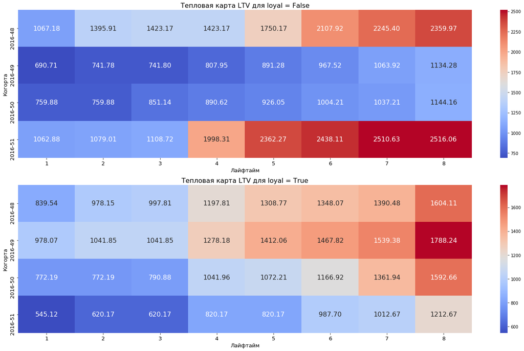

```python
plt.figure(figsize=(20, 12))

for i, loyal in enumerate(profiles['loyal'].unique()):
    sns.heatmap(
        ltv.query('loyal == @loyal')
        .droplevel('loyal')
        .drop(columns=[0]),
        annot=True,
        fmt='.2f',
        annot_kws={'fontsize': 16},
        ax=plt.subplot(2, 1, i + 1),
        cmap='coolwarm'
    )
    plt.title('Тепловая карта LTV для loyal = {}'.format(loyal), fontsize=16)
    plt.xlabel('Лайфтайм', fontsize=13)
    plt.ylabel('Когорта', fontsize=13)
    plt.tick_params(labelsize=13)

plt.tight_layout()
plt.show()
```

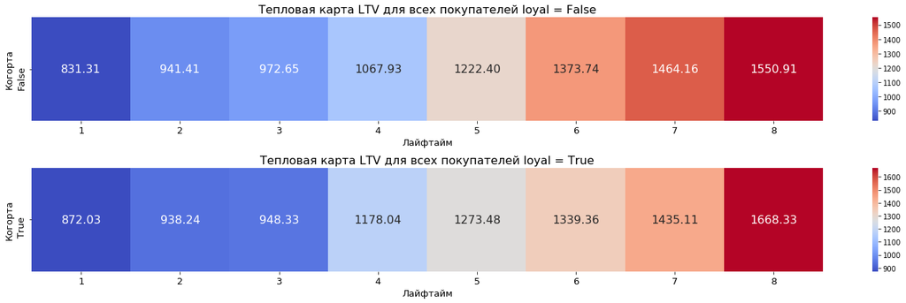

```python
plt.figure(figsize=(20, 6))

for i, loyal in enumerate(profiles['loyal'].unique()):
    sns.heatmap(
        ltv_all.query('loyal == @loyal')
        .drop(columns=[0]),
        annot=True,
        fmt='.2f',
        annot_kws={'fontsize': 16},
        ax=plt.subplot(2, 1, i + 1),
        cmap='coolwarm'
    )
    plt.title('Тепловая карта LTV для всех покупателей loyal = {}'.format(loyal), fontsize=16)
    plt.xlabel('Лайфтайм', fontsize=13)
    plt.ylabel('Когорта', fontsize=13)
    plt.tick_params(labelsize=13)

plt.tight_layout()
plt.show()
```